# Week 5 Day 2 Homework

# Read in Libraries

```r
library(CodeClanData)
```

# Question 1.

Load in the libraries you need, and look at the backpack data. Take note of variable names and dimensions.

## Thoughts

```r
backpack <- backpack
glimpse(backpack)
```

```
Rows: 100
Columns: 9
$ backpack_weight <int> 9, 8, 10, 6, 8, 5, 8, 4, 5, 2, 8, 21, 11, 11, 12, 11, 13, 6, 10, 5, 20, 14, 11, 15, 10, 18, 8, 5, 25, 6, 10, 15, 9, 7, 14, …
$ body_weight     <int> 125, 195, 120, 155, 180, 240, 170, 185, 130, 120, 135, 160, 170, 170, 125, 175, 145, 105, 125, 165, 170, 117, 145, 205, 270…
$ ratio           <dbl> 0.0720000, 0.0410256, 0.0833333, 0.0387097, 0.0444444, 0.0208333, 0.0470588, 0.0216216, 0.0384615, 0.0166667, 0.0592593, 0.…
$ back_problems   <int> 1, 0, 1, 0, 0, 0, 0, 1, 0, 0, 0, 0, 0, 1, 1, 0, 1, 0, 1, 0, 0, 1, 0, 0, 0, 1, 0, 0, 0, 1, 1, 1, 0, 0, 1, 0, 0, 0, 0, 0, 1, …
$ major           <fct> Bio, Philosophy, GRC, CSC, EE, History, CM, ARCE, Bio, Bio, Bus, ME, CPE, CPE, CS, CPE, Bio, LS, LS, Bio, CSC, EE, CE, Bio,…
$ year            <int> 3, 5, 4, 6, 2, 0, 3, 5, 4, 5, 3, 5, 4, 4, 3, 4, 4, 3, 3, 3, 2, 2, 5, 5, 3, 1, 4, 2, 2, 1, 1, 3, 6, 6, 5, 4, 2, 4, 3, 2, 4, …
$ sex             <fct> Female, Male, Female, Male, Female, Male, Male, Female, Female, Female, Female, Male, Male, Male, Female, Male, Female, Fem…
$ status          <fct> U, U, U, G, U, G, U, U, U, U, U, U, U, U, U, U, U, U, U, U, U, U, U, U, U, U, U, U, U, U, U, U, G, U, U, U, U, U, U, U, U, …
$ units           <int> 13, 12, 14, 0, 14, 0, 15, 18, 14, 8, 15, 12, 16, 16, 12, 16, 16, 16, 17, 14, 16, 12, 14, 12, 12, 13, 16, 16, 14, 15, 14, 16…
```

```r
my_theme <- theme_classic() +
  theme(panel.grid.minor = element_line(colour = "grey60"),
        axis.title = element_text(hjust = 0.5),
        title = element_text(hjust = 0.5))
```

# Question 2.

What is the distribution of backpack weights that students are carrying? Choose an appropriate graph to show the distribution.

## Thoughts

Create a histogram showing the nornmal distribution of the backpack weights (lbs has been set as the unit of weight for general discussion purposes,)

## Code and output

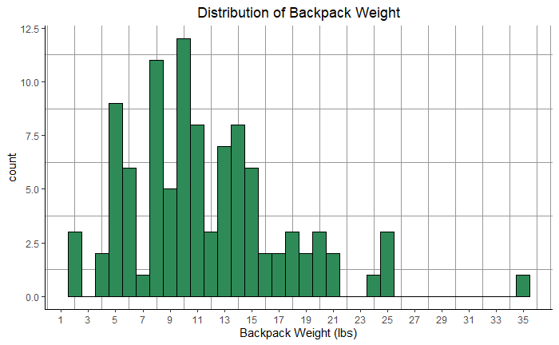

```r
backpack %>%
ggplot(aes(x = backpack_weight)) +
  geom_histogram(binwidth = 1,
                 fill = "seagreen",
                 colour = "black") +
  labs(title = "Distribution of Backpack Weight",
       x = "Backpack Weight (lbs)") +
  scale_x_continuous(breaks = seq(1, max(backpack$backpack_weight), 2)) +
  my_theme
```

```r
  #scale_fill_manual(values = c("seagreen")) +
  #theme_classic()
```

## Output Discussion

# Question 3.

Are there differences in backpack weight between sex?

## Thoughts

Possible plot could be to have two histograms for males and females.

## Code and output

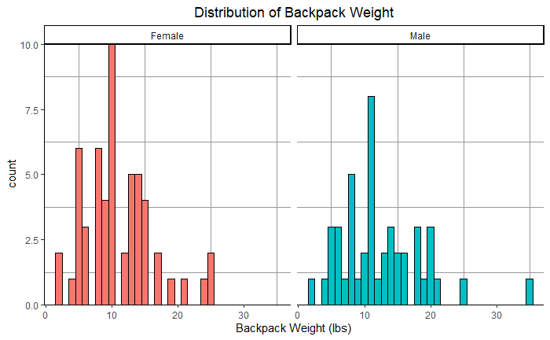

```r
backpack %>%
ggplot(aes(x = backpack_weight)) +
  geom_histogram(binwidth = 1,
                 aes(fill = sex,
                 ), colour = "black",
                 show.legend = FALSE) +
  labs(title = "Distribution of Backpack Weight",
       x = "Backpack Weight (lbs)") +
  facet_wrap(~ sex)+
  scale_y_continuous(expand = c(0,0)) + #breaks = seq(1, max(backpack$backpack_weight), 2)) +
  my_theme
```

## Discussion

The females tend to have lighter bags than the males within the data set. The general trend of the distribution is fairly similar but has more outlier on the male size.

# Question 4.

What is the relationship between body weight and backpack weight?

## Thought

Create a scatter plot showing the body weight vs back pack.

## Code and output

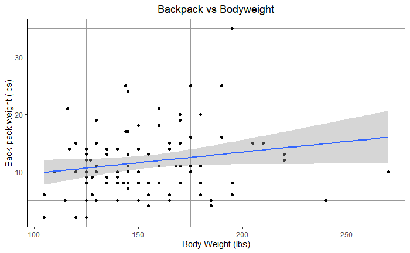

```r
backpack %>%
  ggplot(aes(x = body_weight,
             y = backpack_weight)) +
  geom_point() +
  geom_smooth(method = "lm", show.legend = FALSE) +
  my_theme+
  labs(title = "Backpack vs Bodyweight",
       x = "Body Weight (lbs)",
       y = "Back pack weight (lbs)")
```

## Discussion

From the plot there does not appear to be a trend between backpack weight and body weight.

# Question 5.

Is this relationship different between men and women? Choose an appropriate plot and interpret your findings.

## Code and output

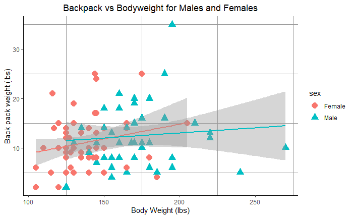

```r
backpack %>%
  ggplot(aes(x = body_weight,
             y = backpack_weight)) +
  geom_point(aes(shape = sex,
                 colour = sex),
             size = 4) +
  geom_smooth(aes(colour = sex),
              method = "lm", show.legend = FALSE) +
  my_theme+
  labs(title = "Backpack vs Bodyweight for Males and Females",
       x = "Body Weight (lbs)",
       y = "Back pack weight (lbs)")
```

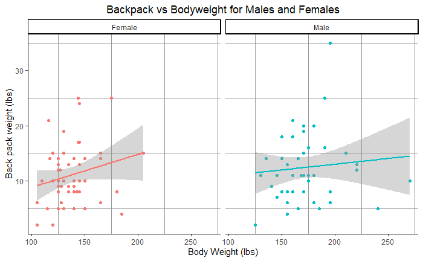

```r
backpack %>%
  ggplot(aes(x = body_weight,
             y = backpack_weight,
             colour = sex)) +
  geom_point(show.legend = FALSE) +
  geom_smooth(method = "lm", show.legend = FALSE) +
  my_theme+
  labs(title = "Backpack vs Bodyweight for Males and Females",
       x = "Body Weight (lbs)",
       y = "Back pack weight (lbs)") +
  facet_wrap(~ sex)
```

# Discussion

There could be a possible steeper gradient of a linear trendline for females. However this is still unlikely has a very low match with both sets showing a large spread for the results. The only information shown is that males are generally heavier than females- and this plot is not a good way to show this.

# Question 6.

What proportion of students report back pain?

## Thoughts

Simple bar chart or column chart showing the amount of students

## Code and Output

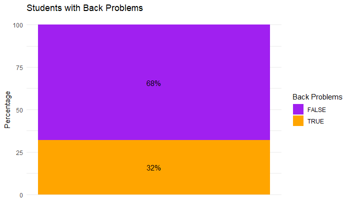

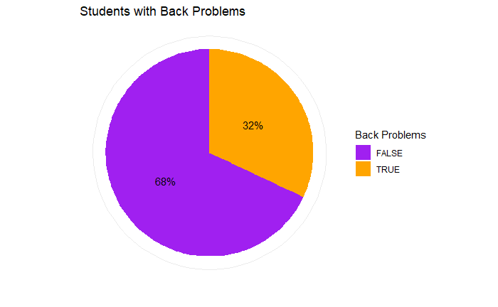

## Discussion

Around a third of students have reported back problems.

# Question 7.

Is this proportion different between men and women?

## Thoughts

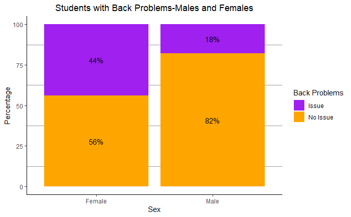

```r
backpack %>%
  group_by(back_problems, sex) %>%
  summarise(count_num = n()) %>%
  group_by(sex) %>%
  mutate(percent = round(100*count_num/sum(count_num), 0)) %>%
  mutate(back_problems = if_else(back_problems == 1, "Issue", "No Issue")) %>%
  ggplot(aes(x = sex,
             y = percent,
             fill = factor(back_problems))) +
  geom_col() +
  scale_fill_manual(values = c("Purple", "Orange"))+ #scale_fill_distiller(palette = "Dark2") +
  geom_text(aes(label = paste0(percent, "%")),
            position = position_stack(vjust = 0.5)) +
  my_theme +
  labs(title = "Students with Back Problems-Males and Females",
       y = "Percentage",
       x = "Sex",
       fill = "Back Problems")
```

## Discussion

Women tend to have more back problems than men with an almost 50% split of having issues/not. There is a large reduction in the population of men with back issues in comparison.

# Question 8.

Now you’ve investigated your data separately, create plots to describe the relationship between backpack weight, body weight, gender and reported backpain.

Try both backpack_weight and body_weight as well as the ratio.

Hint: faceting would be useful here.

## Code and Output

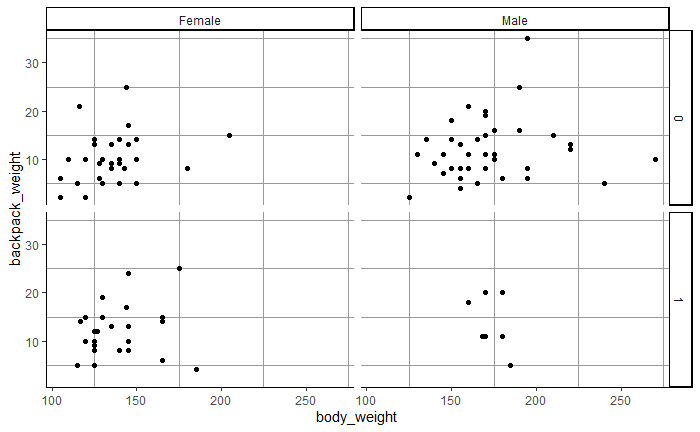

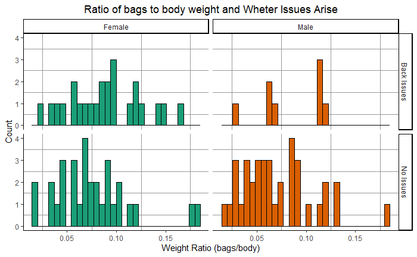

```r
max_ratio <- round(max(backpack$backpack_weight/backpack$body_weight), 2)

backpack %>%
  mutate(weight_ratio = backpack_weight/body_weight,
         back_problems = if_else(back_problems == 1, "Back Issues", "No Issues")) %>%
  ggplot() +
  geom_histogram(aes(x = weight_ratio,
                     fill = factor(sex),
                     ), colour = "black",
                 show.legend = FALSE) +
  facet_grid(back_problems ~ sex) +
  scale_fill_brewer(palette = "Dark2") +
  #scale_x_continuous(breaks = max_ratio * seq(0.1, 1, 0.1)) +
  my_theme +
  labs(title = "Ratio of bags to body weight and Wheter Issues Arise",
       y = "Count",
       x = "Weight Ratio (bags/body)")
```

## Discussion

The first scatter plot tends to tell limits information in terms of trends. The histograms do show that generally more issues occur when there is a higher ratio of bag to body weight.

## 3 Extensions

# Question 1.

Does reported backpain differ across the year groups? Ignore year 0 in your data.

## Thoughts

Can complete similar to before but will need to replace sex with year. Might also need to check the number of pupils in each year.

## Code and Output

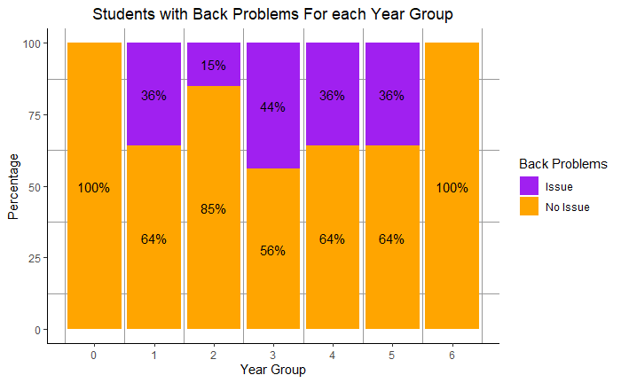

```r
backpack %>%
  group_by(back_problems, year) %>%
  summarise(count_num = n()) %>%
  group_by(year) %>%
  mutate(percent = round(100*count_num/sum(count_num), 0)) %>%
  mutate(back_problems = if_else(back_problems == 1, "Issue", "No Issue")) %>%
  ggplot(aes(x = year,
             y = percent,
             fill = factor(back_problems))) +
  geom_col() +
  scale_fill_manual(values = c("Purple", "Orange"))+ #scale_fill_distiller(palette = "Dark2") +
  geom_text(aes(label = paste0(percent, "%")),
            position = position_stack(vjust = 0.5)) +
  my_theme +
  scale_x_continuous(breaks = seq(0, 6, 1)) +
  labs(title = "Students with Back Problems For each Year Group",
       y = "Percentage",
       x = "Year Group",
       fill = "Back Problems")
```

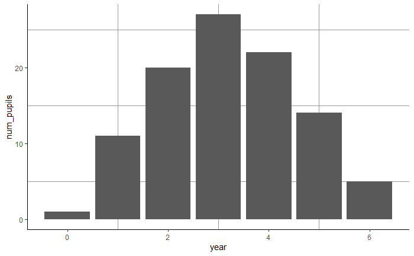

```r
backpack %>%
  group_by(year) %>%
  summarise(num_pupils = n()) %>%
  ggplot(aes(x = year,
         y = num_pupils)) +
  geom_col() +
  my_theme
```

## Discussion

The year groups from 1 to 5 have issues whereas 0 and 6 have no issues. However For the number of pupils in years 0 and 6 are very low when compared to the other years. Therefore if there were more there is the possibility that this would be around 30% similar to other years.

# Question 2.

Is there a difference between how heavy the bags those in different years carry?

## Thoughts

Could do a histogram for each year with a distribution of weight.

## Code and Output

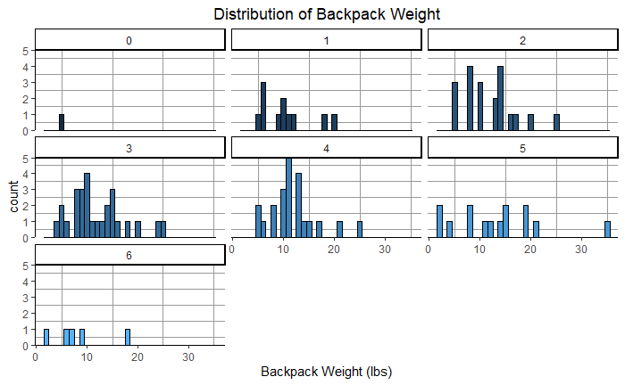

```r
backpack %>%
ggplot(aes(x = backpack_weight)) +
  geom_histogram(binwidth = 1,
                 aes(fill = year,
                 ), colour = "black",
                 show.legend = FALSE) +
  labs(title = "Distribution of Backpack Weight",
       x = "Backpack Weight (lbs)") +
  facet_wrap(~ year)+
  scale_y_continuous(expand = c(0,0)) + #breaks = seq(1, max(backpack$backpack_weight), 2)) +
  my_theme
```

```r
NA
```

## Discussion

Majority of years show a similar skew to back weights of around 10lbs. The distribution of bag weight it more spread out for year 5 in comparisson to other years.